# Rx_Burn_Data

Kate Jones

updated 01/21/2021

This markdown describes acquiring, cleaning, and processing RX data in Western North Carolina to create an RX input raster for the S. Apps SCRPPLE extension.

**Data**

The data to create the RX surface were predominantly gathered through personal correspondence with managers in western North Carolina. We were unable to acquire data for TN, GA, or SC, so the data values calculated for NC were extrapolated to the other states in our study area. Data to estimate federal forest burning was gathered separately from a USFS report - no spatial data for Federal lands were acquired, so we expect RX burning on federal lands is underestimated in this work flow. It should also be noted, that the numbers reflected in the USFS report are annual targets, which may or may not be met each year, so we handled these data separately than the observed RX data gathered from the NC agencies.

Contacts where RX data were acquired:

**1) NC Forest Service (NCFS)**  
- Christian D. Vose | Information Technology Branch Head | christian.vose@ncagr.gov

**2) NC State Parks (NCSP)**  
- John Amoroso | Planning & GIS | john.amoroso@ncparks.gov

**3) NC Wildlife Resources Commission (NCWRC)**  
- Ryan Jacobs | Wildlife Forest Manager | Ryan.Jacobs@ncwildlife.org

**Step 1: Load & Project Data**

The data collected from each agency were in slightly different formats, but all spatial. We read all the datasets in and project to UTM 17N and crop them to the AOI.

**Step 2: Plot and Check**

To make sure everything spatially aligns and looks as expected, we plot the data. Looks ok, but we’ll want to zoom in spatially to the AOI and change plotting for the polygons layers.

*The NCWRC and NC State Parks provided area data, while the NCFS provided point data. We will convert all data to points (using area centroids) for consistency.

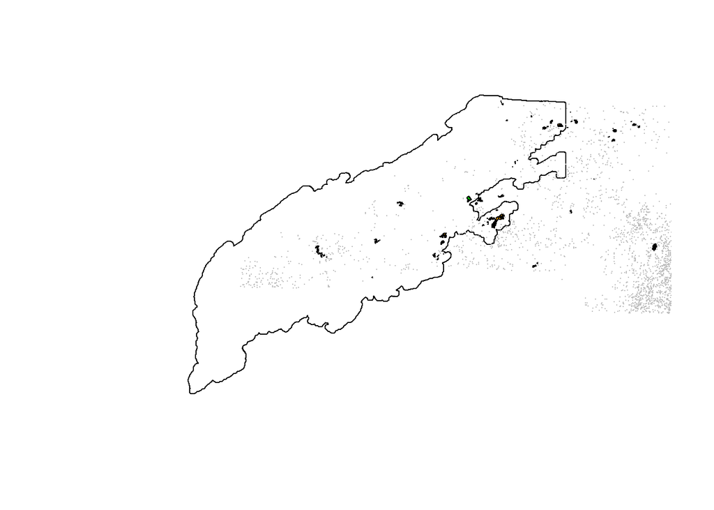

**Step 3: Better Plotting**

Once zoomed into the AOI, we can better see the RX locations for the three agencies. You’ll notice there are hard cutoffs in the AOI between areas with ignitions and areas without ignitions - this is because we were only able to collect data from NC, so these boundaries follow state lines. We can see the RX burns are fairly clustered (i.e. the observations generally occur in the same locations, which are contained within management boundaries). The exception is the NCFS in grey, which had an unexpected number of burns that appeared on private lands (according to the land ownership data we use). This may explain why the NCFS RX ignitions are more distributed throughout the state and not confined to certain land ownership. More on this later.

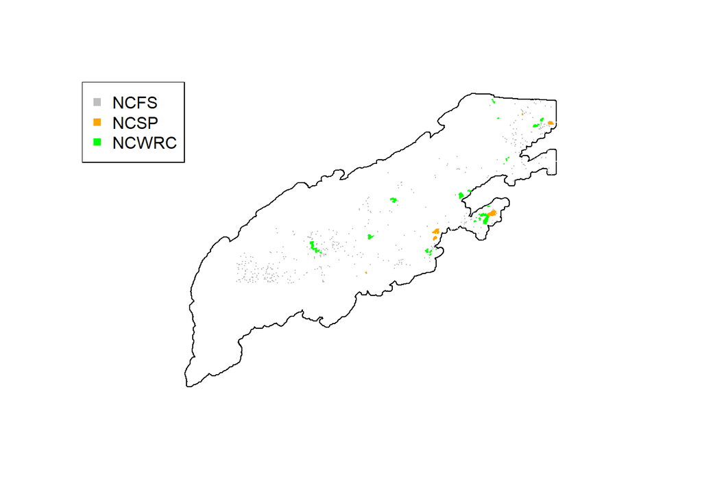

**Step 4: Dividing Data by Jurisdiction/Ownership**

There could be multiple iterations of this process, but for now, we’ve grouped the land ownership layer into Federal, State, Private, and Local (local is likely an unnecessary class, but without further discussion on where to group it, it stands alone). The land ownership data will be intersected with the RX locations.

Land ownership data was acquired via correspondence with NIFCC and downloaded from this link: https://wfdss.usgs.gov/wfdss_help/WFDSSHelp_SMA_Layer.html, then navigate to the Data Downloads page.

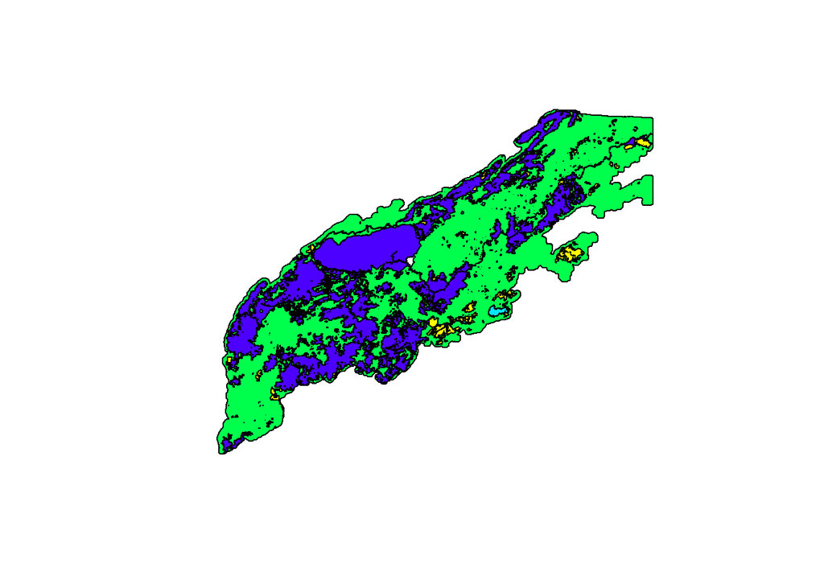

**Step 5: Format Rx Datasets as Points** For now, converting everything to points (i.e. centroids of polygons) so it’s in the same format and assigning the polygon dataframe (attributes) to the centroids.

**Step 6: Getting all of the data in the same format**

Across the datasets, there are different formats for dates, burn names, objectids, etc. Need to get everything into a format that has the following columns:

-OBJECTID  
-Burn Unit (if possible)  
-Year  
-Month  
-Date  
-Acreage

To get the above columns in a unified format, the WRC data needs the most cleaning. Cleaning steps commented in code.

**Step 7: Final data formatting**

Combine all formatted data into single spatial object with tabular information.

**Quick Diagnostic: Monthly RX occurrences all years, all data sources**

```
## [1]  1 12
```

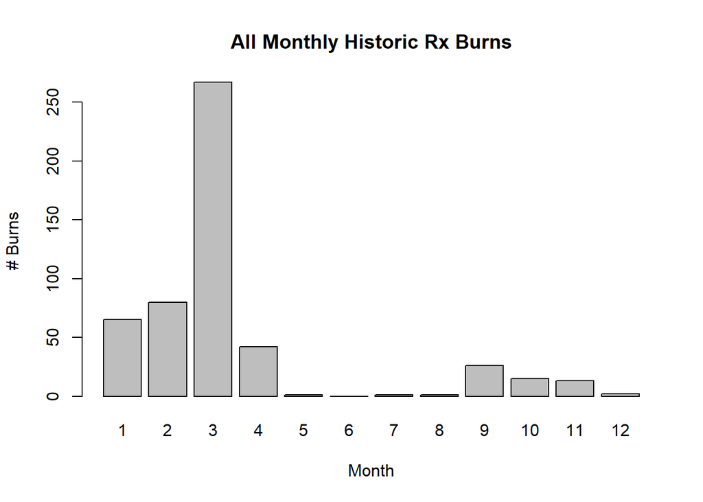

**Quick Diagnostic: Historic RX Acreage Burned by Ownership**

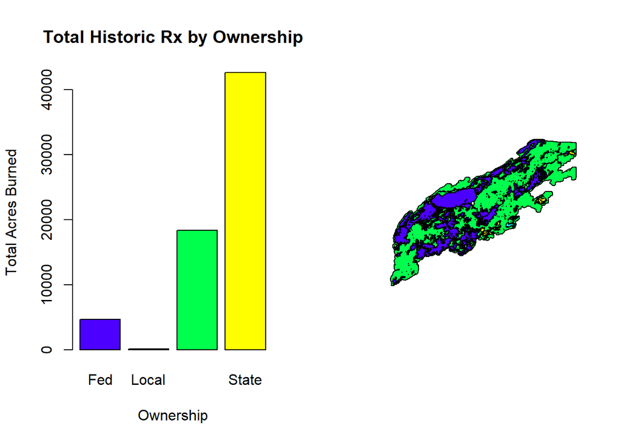

**Quick Diagnostic: Historic Burn Sizes by Ownership**

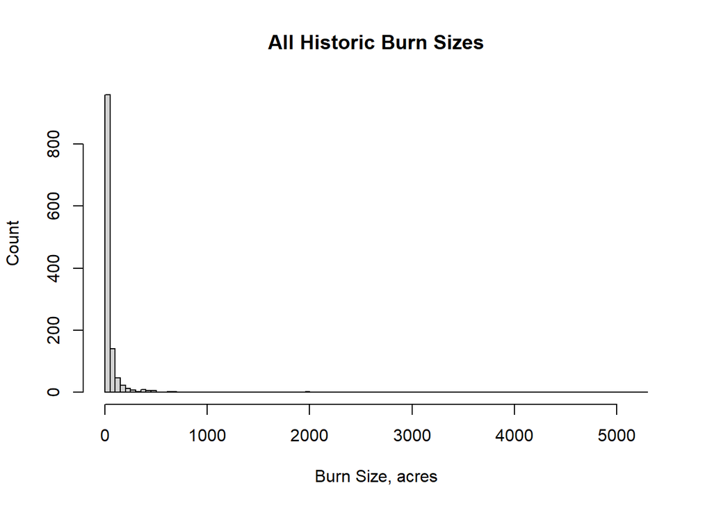

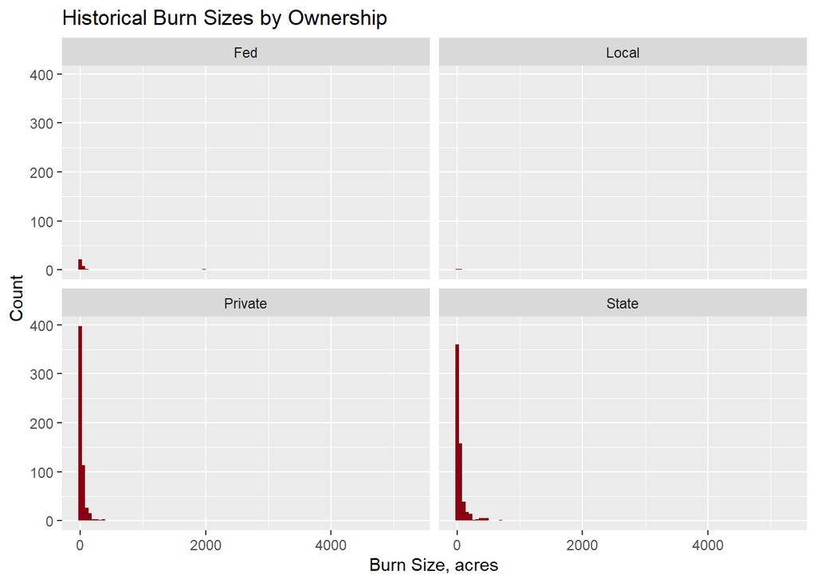

**Step 8: Determine Burned Area %’s by Land Ownership**

**Quick Diagnostic: Annual Acres Burned by Ownership**

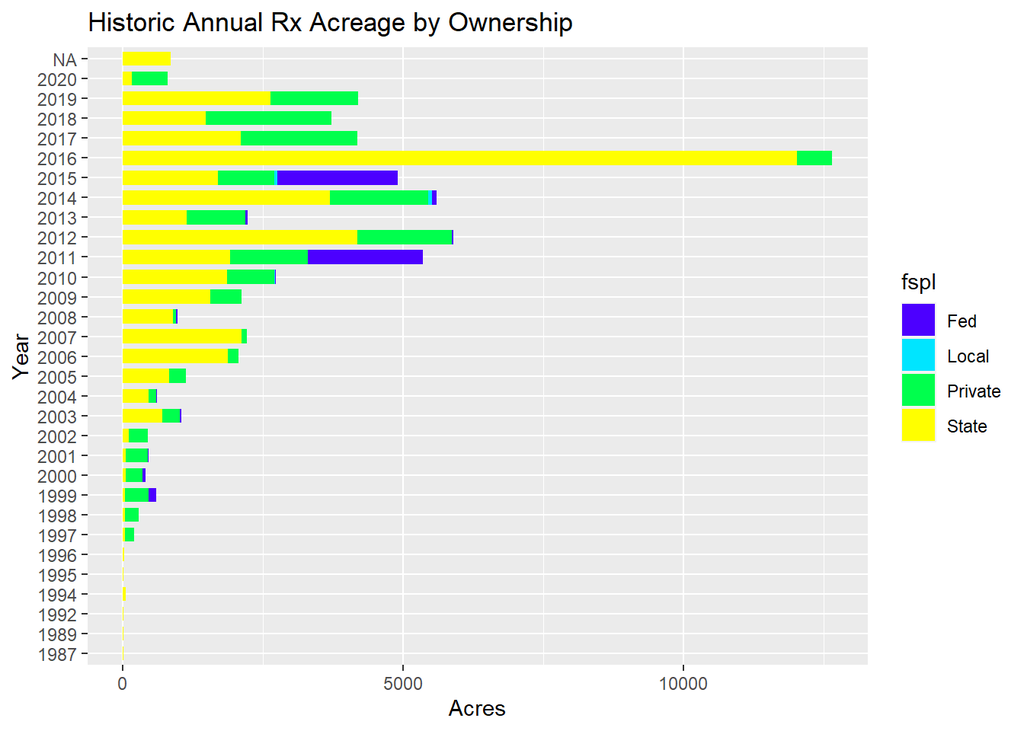

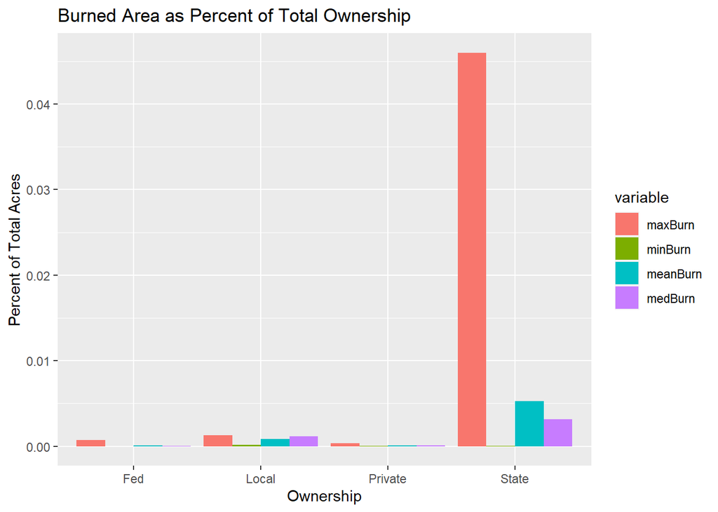

**Step 9: Assigning raster cells a percentage of total acres burned across the landscape**

This represents the probability that a given cell will burn. The tables below each raster show the relative burn probabilities and the hypothetical burned areas used to calculate the probabilities for each ownership for the 10/50/100 scenarios.

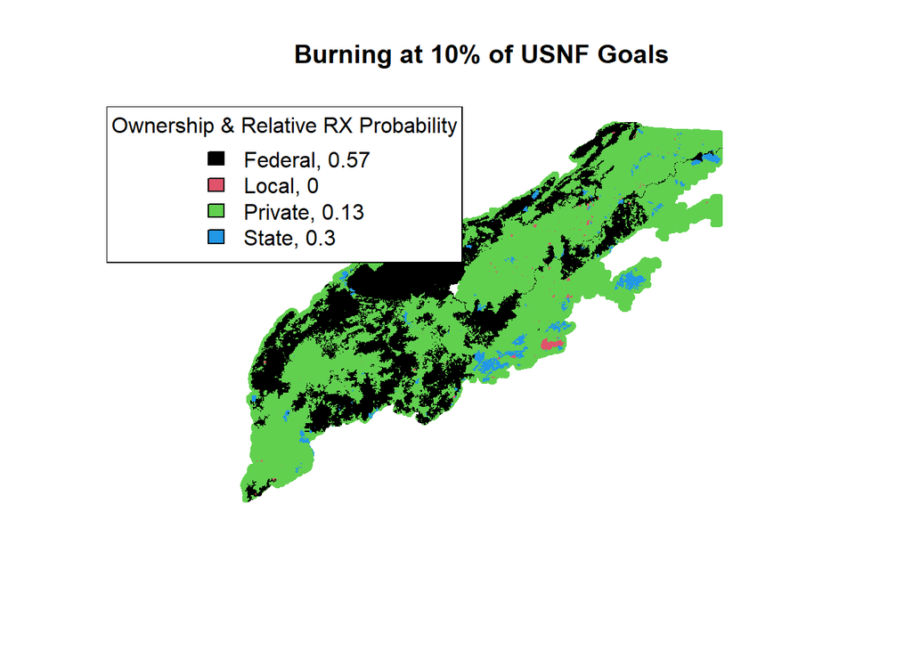

This table shows the values (empirical and derived) to represent RX fire across the landscape when the NF is meeting 10% of their acreage goals. All RX values are held constant across the 10/50/100 % scenarios, as these are observed data.

| fspl | total_burnedacres_injuris | total_burnedacres_landscape | perc_of_land_burn | round_perc_land_burn |
| --- | --- | --- | --- | --- |
| Fed | 80000 | 141153 | 0.5667609 | 0.57 |
| Local | 126 | 141153 | 0.0008926 | 0.00 |
| Private | 18372 | 141153 | 0.1301566 | 0.13 |
| State | 42655 | 141153 | 0.3021898 | 0.30 |

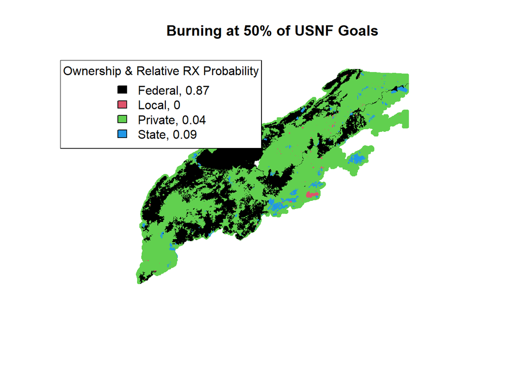

This table shows the values (empirical and derived) to represent RX fire across the landscape when the NF is meeting 50% of their acreage goals. All RX values are held constant across the 10/50/100 % scenarios, as these are observed data.

| fspl | total_burnedacres_injuris | total_burnedacres_landscape | perc_of_land_burn | round_perc_land_burn |
| --- | --- | --- | --- | --- |
| Fed | 400000 | 461153 | 0.8673911 | 0.87 |
| Local | 126 | 461153 | 0.0002732 | 0.00 |
| Private | 18372 | 461153 | 0.0398393 | 0.04 |
| State | 42655 | 461153 | 0.0924964 | 0.09 |

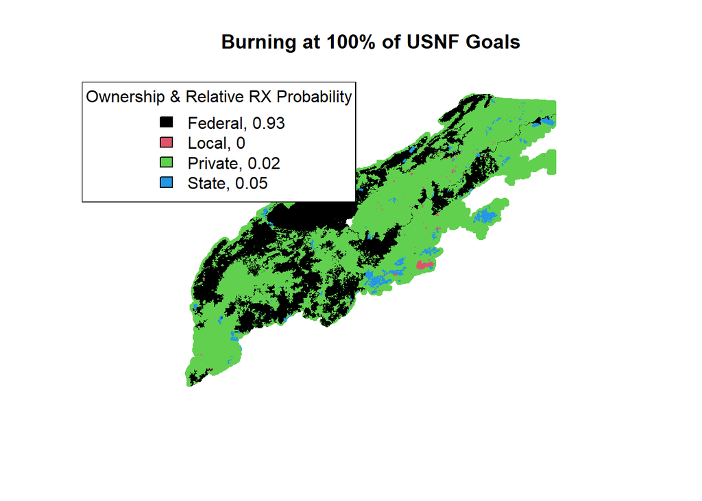

This table shows the values (empirical and derived) to represent RX fire across the landscape when the NF is meeting 100% of their acreage goals. All RX values are held constant across the 10/50/100 % scenarios, as these are observed data.

| fspl | total_burnedacres_injuris | total_burnedacres_landscape | perc_of_land_burn | round_perc_land_burn |
| --- | --- | --- | --- | --- |
| Fed | 800000 | 861153 | 0.9289871 | 0.93 |
| Local | 126 | 861153 | 0.0001463 | 0.00 |
| Private | 18372 | 861153 | 0.0213342 | 0.02 |
| State | 42655 | 861153 | 0.0495324 | 0.05 |